# Introduction

### Visual 8

**Purpose**

This chart shows Sales while considering the various genres over time

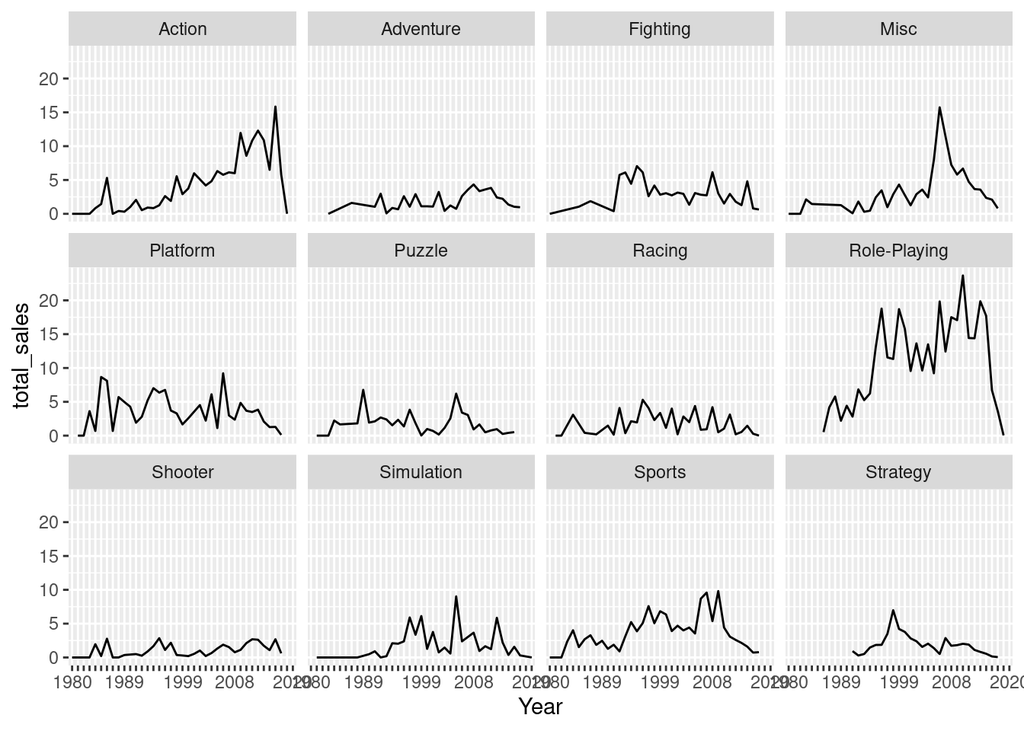

```r
vgsales %>% dplyr::select(Year, JP_Sales,Genre) %>% filter(Year!='N/A') %>%
        dplyr::group_by(Year,Genre) %>%
        dplyr::summarize(total_sales=sum(JP_Sales))%>%
        ggplot(aes(Year,total_sales,group=1))+geom_line()+facet_wrap(~Genre)+
        scale_x_discrete(guide = guide_axis(check.overlap = TRUE))
```

**Observation**

Role-Playing games were the best performers over the years. Platforms, strategy, adventures, and fighting have the most consistent performance.

### Visual 9

**Purpose**

This chart shows the best selling game in terms of revenue by year.

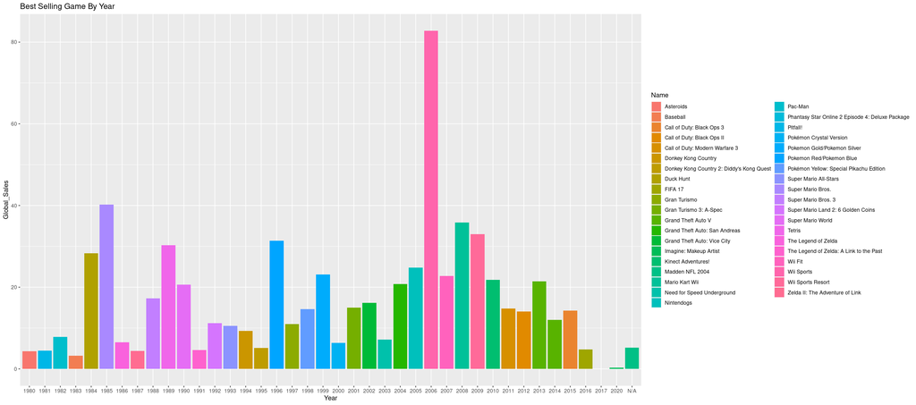

```r
knitr::include_graphics("good.png")
```

**Observation**

Wii sports was the best selling game in term of revenue by far

### Visual 9

**Purpose**

This chart shows the average sales by genre.

```r
genre_totals<-vgsales%>%dplyr::select(Genre,JP_Sales) %>%dplyr::count(Genre)

sales<-vgsales%>%dplyr::select(Genre,JP_Sales) %>%dplyr::group_by(Genre)%>%
        dplyr::summarize(total_sales=sum(JP_Sales))
sales$total_sales/genre_totals$n
```

```
##  [1] 0.04823583 0.04048989 0.10300708 0.06196665 0.14759594 0.09847079
##  [7] 0.04538831 0.23676747 0.02922137 0.07347174 0.05770247 0.07262849
```

```r
genre_totals$total_sales<-sales$total_sales
sum(genre_totals$total_sales)
```

```
## [1] 1291.02
```

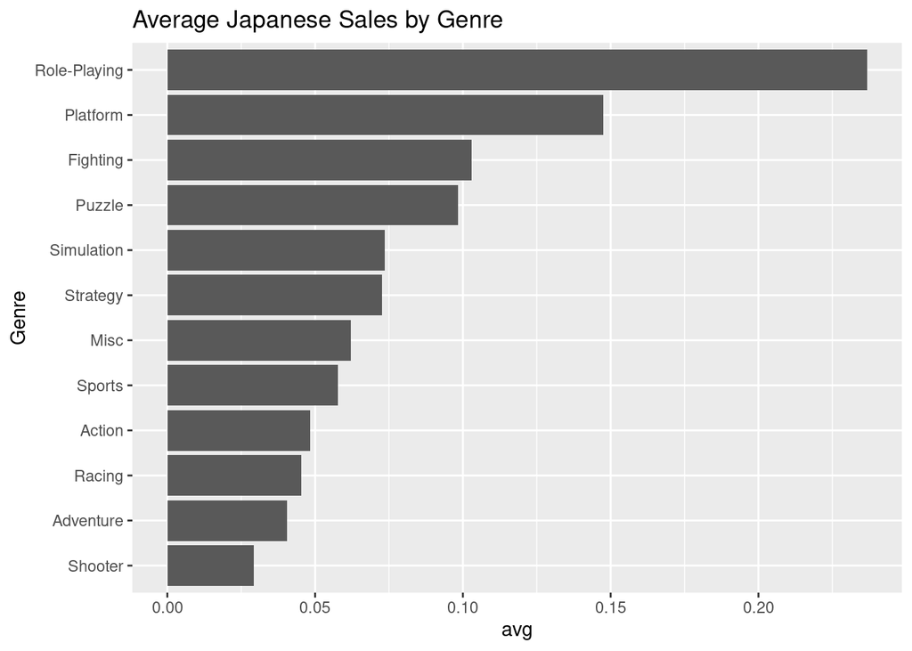

```r
genre_totals%>% dplyr::mutate(avg=(total_sales/n)) %>%
        ggplot(aes(reorder(Genre,+avg),avg))+geom_bar(stat='identity')+ggtitle('Average Japanese Sales by Genre')+labs(x='Genre')+coord_flip()
```

**Observation**

A role-playing game was on average generate much more revenue than other genres. Despite action and sports have a large number of units sold the actual average sales generate was low.

# Data Prep

We now moving to model development. There are too many Publishers to make a understandable model. Therefore, we will take the top twenty publishers for are model. Below is the code and output for this experience

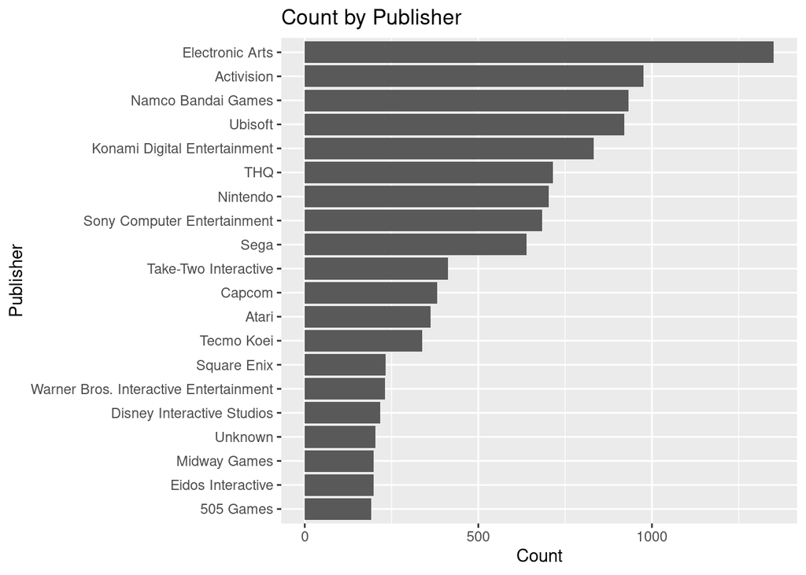

```r
publisher_select<-vgsales %>%dplyr:: select(Publisher) %>%dplyr::group_by(Publisher)%>%dplyr::count(Publisher,sort=T)%>%
        dplyr::ungroup() %>% dplyr::transmute(Publisher,n,new=n/sum(n))
pub_names<-(publisher_select$Publisher[1:20])
pub_names_plot<-(publisher_select[1:20,])

ggplot(pub_names_plot,aes(reorder(Publisher,+n),n))+geom_bar(stat='identity')+coord_flip()+ggtitle('Count by Publisher')+labs(x='Publisher',y='Count')
```

If we take the top 20 publishers we still have 65% of the data as shown below

```r
sum(publisher_select$new[1:20])
```

```
## [1] 0.6458609
```

### Dealing with the Platforms

The platforms also need to be simplified for interpretation. For example all the PS have been recoded as Sony and the same with the Nintendo platforms. When it was not clear what manufacturer a platform belong to it was recoded as other

```r
vgsales_clean<-vgsales %>% mutate(simple_platform=recode(Platform, `Wii`="Nintendo",`NES`="Nintendo",`GB`="Nintendo",`DS`="Nintendo",`X360`="Microsoft",`PS3`="Sony",`PS2`="Sony",`SNES`="Nintendo",
`GBA`="Nintendo",`3DS`="Nintendo",`PS4`="Sony",`N64`="Nintendo",`PS`="Sony",`XB`="Microsoft",`2600`="Other",
`PSP`="Sony",`XOne`="Microsoft",`GC`="Nintendo",`WiiU`="Nintendo",`GEN`="Other",`DC`="Sega",`PSV`="Sony",
`SAT`="Sega",`SCD`="Other",`WS`="Other",`NG`="Other",`TG16`="Other",`3DO`="Other",`GG`="Sega",`PCFX`="Other",))
```

### Log Transformation

We also need to do a log transformation of the continuous variables. In addition, because log cannot handle zeros we have to add a constant of 1 to each value so we do not get an error. We will reverse this when it is time for interpretation.

```r
vgsales_clean<-vgsales_clean%>%filter(Publisher %in% pub_names)
vgsales_clean$log_JP_Sales<-log(vgsales_clean$JP_Sales+1)
vgsales_clean$log_NA_Sales<-log(vgsales_clean$NA_Sales+1)
vgsales_clean$log_EU_Sales<-log(vgsales_clean$EU_Sales+1)
vgsales_clean$log_Other_Sales<-log(vgsales_clean$Other_Sales+1)
```

# Model Development

Below we divide are dataset into train and test sets

```r
set.seed(123)
ind<-sample(2,nrow(vgsales_clean),replace=T,prob = c(0.7,0.3))
train<-vgsales_clean[ind==1,]
test<-vgsales_clean[ind==2,]
```

I like to always begin with a regression model just to get an insight into the data before completing a more complex analysis.

```r
summary(lm(log_JP_Sales~log_NA_Sales+log_EU_Sales+log_Other_Sales+Genre+Publisher+simple_platform,train))
```

```
##
## Call:
## lm(formula = log_JP_Sales ~ log_NA_Sales + log_EU_Sales + log_Other_Sales +
##     Genre + Publisher + simple_platform, data = train)
##
## Residuals:
##      Min       1Q   Median       3Q      Max
## -0.44798 -0.05844 -0.00517  0.03241  1.60392
##
## Coefficients:
##                                                  Estimate Std. Error t value
## (Intercept)                                     -0.050553   0.012915  -3.914
## log_NA_Sales                                     0.082773   0.008387   9.869
## log_EU_Sales                                     0.131540   0.011930  11.026
## log_Other_Sales                                  0.155640   0.023119   6.732
## GenreAdventure                                  -0.001277   0.007930  -0.161
## GenreFighting                                    0.020035   0.007674   2.611
## GenreMisc                                       -0.004544   0.005961  -0.762
## GenrePlatform                                    0.026064   0.007257   3.591
## GenrePuzzle                                      0.018440   0.010409   1.772
## GenreRacing                                      0.010091   0.007005   1.441
## GenreRole-Playing                                0.087637   0.006657  13.166
## GenreShooter                                    -0.013358   0.006479  -2.062
## GenreSimulation                                  0.025464   0.007743   3.289
## GenreSports                                      0.018151   0.005325   3.409
## GenreStrategy                                    0.028312   0.008656   3.271
## PublisherActivision                             -0.027348   0.013019  -2.101
## PublisherAtari                                   0.008779   0.014710   0.597
## PublisherCapcom                                  0.102759   0.014621   7.028
## PublisherDisney Interactive Studios             -0.026606   0.016039  -1.659
## PublisherEidos Interactive                       0.003197   0.016469   0.194
## PublisherElectronic Arts                        -0.036983   0.012818  -2.885
## PublisherKonami Digital Entertainment            0.079258   0.013130   6.037
## PublisherMidway Games                           -0.010736   0.016633  -0.645
## PublisherNamco Bandai Games                      0.105711   0.013077   8.084
## PublisherNintendo                                0.275148   0.013645  20.165
## PublisherSega                                    0.036321   0.013771   2.637
## PublisherSony Computer Entertainment             0.036677   0.013647   2.688
## PublisherSquare Enix                             0.105207   0.016487   6.381
## PublisherTake-Two Interactive                   -0.024906   0.014396  -1.730
```

[output cut: 41 more lines]

```
## PublisherTHQ                                    0.130400
## PublisherUbisoft                                0.243159
## PublisherUnknown                                0.234819
## PublisherWarner Bros. Interactive Entertainment 0.118537
## simple_platformNintendo                         3.18e-11 ***
## simple_platformOther                            0.545922
## simple_platformPC                               0.252273
## simple_platformSega                              < 2e-16 ***
## simple_platformSony                             2.02e-07 ***
## ---
## Signif. codes:  0 '***' 0.001 '**' 0.01 '*' 0.05 '.' 0.1 ' ' 1
##
## Residual standard error: 0.1337 on 7519 degrees of freedom
## Multiple R-squared:  0.436,  Adjusted R-squared:  0.4332
## F-statistic:   153 on 38 and 7519 DF,  p-value: < 2.2e-16
```

The results indicate that there are many significant differences within the Publisher categorical variable and also among the platforms. Role-playing is signficant among the genres along with other groups. The continuous variables also show a significant relationship Japanese sales. The overall variance explained is 43% which might be considered low in a finance context.

## Parameter Tuning

Below we set up the parameter tuning for our boosted random forest

```r
#grid development
grid<-expand.grid(.n.trees=seq(100,500,by=100),.interaction.depth=seq(1,4,by=1),.shrinkage=c(.001,.01,.1),
                  .n.minobsinnode=10)
control<-trainControl(method = "cv", repeats=10)
```

## Model Training

Now we train our model using the settings from the parameter tuning

```r
gbm.sales<-gbm(log_JP_Sales~log_NA_Sales+log_EU_Sales+log_Other_Sales+as.factor(Publisher)+as.factor(Genre)+as.factor(simple_platform),data=train,n.trees = 500,interaction.depth = 4,
               shrinkage = .1,distribution = 'gaussian')
 summary(     gbm.sales, cBars = 40,method = relative.influence, las = 3)
```

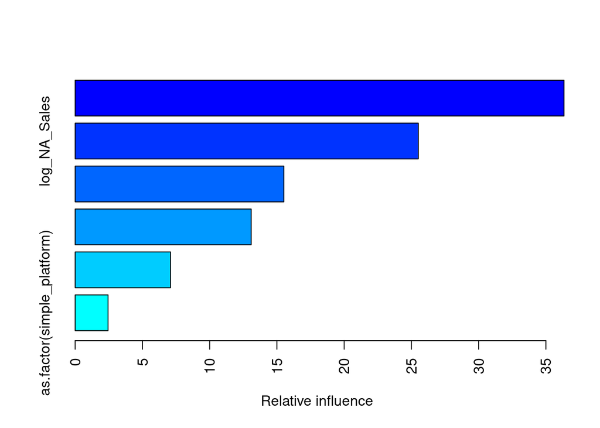

```
##                                                   var   rel.inf
## as.factor(Publisher)             as.factor(Publisher) 36.346704
## log_NA_Sales                             log_NA_Sales 25.513171
## log_EU_Sales                             log_EU_Sales 15.515523
## as.factor(Genre)                     as.factor(Genre) 13.086854
## log_Other_Sales                       log_Other_Sales  7.092988
## as.factor(simple_platform) as.factor(simple_platform)  2.444761
```

## Model Evaluation

Below, we are going to use or test data in order to evaluate the model

```r
gbm.test<-predict(gbm.sales,newdata = test,n.trees = 500,interaction.depth = 4,
                  shrinkage = .1,distribution = 'gaussian')
```

### Residuals

First we take a look at the residuals which is useful for comparing models.

```r
gbm.resid<-gbm.test-test$log_JP_Sales
mean(gbm.resid^2)
```

```
## [1] 0.01431338
```

We want this number to be as low as possible as it indicates less error in the model.

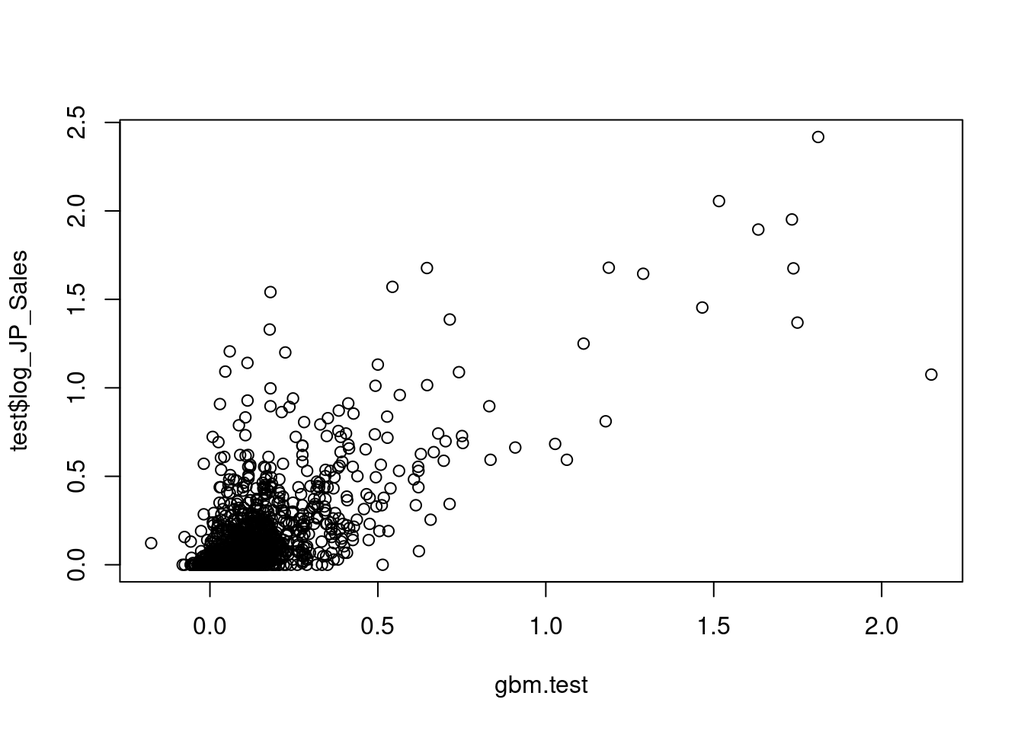